# Structure and content of RAVmodel

Sehyun Oh

March 17, 2022

# 1 Setup

## 1.1 Install and load package

```r
if (!require("BiocManager"))
    install.packages("BiocManager")
BiocManager::install("GenomicSuperSignature")
```

```r
library(GenomicSuperSignature)
```

## 1.2 Download RAVmodel

You can download GenomicSuperSignature from Google Cloud bucket using `GenomicSuperSignature::getModel` function. Currently available models are built from top 20 PCs of 536 studies (containing 44,890 samples) containing 13,934 common genes from each of 536 study’s top 90% varying genes based on their study-level standard deviation. There are two versions of this RAVmodel annotated with different gene sets for GSEA: MSigDB C2 (`C2`) and three priors from PLIER package (`PLIERpriors`). In this vignette, we are showing the `C2` annotated model.

Note that the first interactive run of this code, you will be asked to allow R to create a cache directory. The model file will be stored there and subsequent calls to `getModel` will read from the cache.

```r
RAVmodel <- getModel("C2", load=TRUE)
```

```
#> [1] "downloading"
```

# 2 Content of RAVmodel

`RAVindex` is a matrix containing genes in rows and RAVs in columns. `colData` slot provides the information on each RAVs, such as GSEA annotation and studies involved in each cluster. `metadata` slot stores model construction information. `trainingData` slot contains the information on individual studies in training dataset, such as MeSH terms assigned to each study.

```r
RAVmodel
```

```
#> class: PCAGenomicSignatures
#> dim: 13934 4764
#> metadata(8): cluster size ... version geneSets
#> assays(1): RAVindex
#> rownames(13934): CASKIN1 DDX3Y ... CTC-457E21.9 AC007966.1
#> rowData names(0):
#> colnames(4764): RAV1 RAV2 ... RAV4763 RAV4764
#> colData names(4): RAV studies silhouetteWidth gsea
#> trainingData(2): PCAsummary MeSH
#> trainingData names(536): DRP000987 SRP059172 ... SRP164913 SRP188526
```

```r
version(RAVmodel)
```

```
#> [1] "1.1.1"
```

```r
geneSets(RAVmodel)
```

```
#> [1] "MSigDB C2 version 7.1"
```

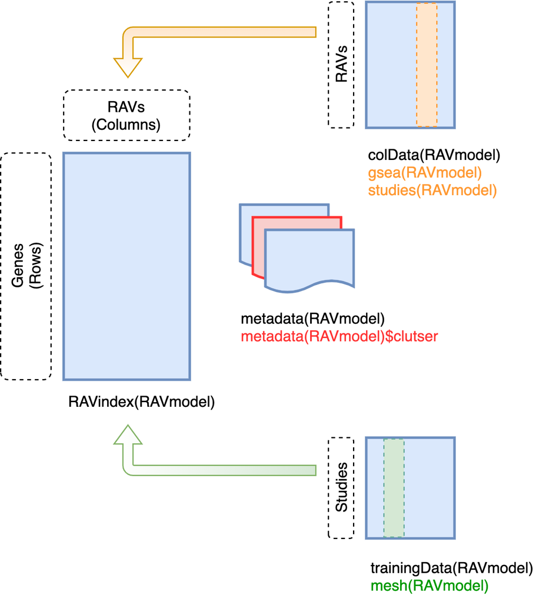

## 2.1 RAVindex

*R*eplicable *A*xis of *V*ariation (RAV) index is the main component of GenomicSuperSignature. It serves as an index connecting new datasets and the existing database. You can access it through `GenomicSuperSignature::RAVindex` (equivalent of `SummarizedExperiment::assay`). Rows are genes and columns are RAVs.

Here, RAVmodel consists of 13,934 genes and 4,764 RAVs.

```r
class(RAVindex(RAVmodel))
```

```
#> [1] "matrix" "array"
```

```r
dim(RAVindex(RAVmodel))
```

```
#> [1] 13934  4764
```

```r
RAVindex(RAVmodel)[1:4, 1:4]
```

```
#>                RAV1          RAV2         RAV3         RAV4
#> CASKIN1 0.002449532 -2.845471e-03  0.001601715 -0.009366156
#> DDX3Y   0.006093438  1.870528e-03 -0.004346019 -0.006094526
#> MDGA1   0.009999975  2.610302e-03 -0.002831447 -0.006710757
#> EIF1AY  0.007923652  8.507021e-05  0.002322275 -0.007850784
```

## 2.2 Metadata for RAVmodel

Metadata slot of RAVmodel contains information related to the model building.

```r
names(metadata(RAVmodel))
```

```
#> [1] "cluster"    "size"       "k"          "n"          "MeSH_freq"
#> [6] "updateNote" "version"    "geneSets"
```

- `cluster` : cluster membership of each PCs from the training dataset
- `size` : an integer vector with the length of clusters, containing the number of PCs in each cluster
- `k` : the number of all clusters in the given RAVmodel
- `n` : the number of top PCs kept from each study in the training dataset
- `geneSets` : the name of gene sets used for GSEA annotation
- `MeSH_freq` : the frequency of MeSH terms associated with the training dataset. MeSH terms like ‘Humans’ and ‘RNA-seq’ are top ranked (which is very expected) because the training dataset of this model is Human RNA sequencing data.
- `updateNote` : a brief note on the given model’s specification
- `version` : the version of the given model

```r
head(metadata(RAVmodel)$cluster)
```

```
#> DRP000987.PC1 DRP000987.PC2 DRP000987.PC3 DRP000987.PC4 DRP000987.PC5
#>             1             2             3             4             5
#> DRP000987.PC6
#>             6
```

```r
head(metadata(RAVmodel)$size)
```

```
#> RAV1 RAV2 RAV3 RAV4 RAV5 RAV6
#>    6   21    4    7    3    3
```

```r
metadata(RAVmodel)$k
```

```
#> [1] 4764
```

```r
metadata(RAVmodel)$n
```

```
#> [1] 20
```

```r
geneSets(RAVmodel)
```

```
#> [1] "MSigDB C2 version 7.1"
```

```r
head(metadata(RAVmodel)$MeSH_freq)
```

```
#>
#>                 Humans                RNA-Seq          Transcriptome
#>                   1163                    591                    576
#>                    RNA Whole Exome Sequencing        Sequencing, RNA
#>                    372                    284                    277
```

```r
updateNote(RAVmodel)
```

```
#> [1] "GSEA with set.seed"
```

```r
metadata(RAVmodel)$version
```

```
#> [1] "1.1.1"
```

## 2.3 Studies in each RAV

You can find which studies are in each cluster using `studies` method. Output is a list with the length of clusters, where each element is a character vector containing the name of studies in each cluster.

```r
length(studies(RAVmodel))
```

```
#> [1] 4764
```

```r
studies(RAVmodel)[1:3]
```

```
#> $Cl4764_01
#> [1] "DRP000987" "SRP059172" "SRP059959" "SRP118741" "SRP144178" "SRP183186"
#>
#> $Cl4764_02
#>  [1] "DRP000987" "ERP022839" "ERP104463" "ERP106996" "ERP109789" "ERP114435"
#>  [7] "SRP059039" "SRP059172" "SRP065317" "SRP071547" "SRP073061" "SRP074274"
#> [13] "SRP075449" "SRP092158" "SRP096736" "SRP107337" "SRP111402" "SRP125008"
#> [19] "SRP133442" "SRP135684" "SRP155483"
#>
#> $Cl4764_03
#> [1] "DRP000987" "SRP001540" "SRP056840" "SRP125396"
```

You can check which PC from different studies are in RAVs using `PCinRAV`.

```r
PCinRAV(RAVmodel, 2)
```

```
#>  [1] "DRP000987.PC2" "ERP022839.PC2" "ERP104463.PC1" "ERP106996.PC2"
#>  [5] "ERP109789.PC2" "ERP114435.PC1" "SRP059039.PC3" "SRP059172.PC2"
#>  [9] "SRP065317.PC1" "SRP071547.PC3" "SRP073061.PC2" "SRP074274.PC5"
#> [13] "SRP075449.PC2" "SRP092158.PC2" "SRP096736.PC2" "SRP107337.PC3"
#> [17] "SRP111402.PC1" "SRP125008.PC2" "SRP133442.PC1" "SRP135684.PC4"
#> [21] "SRP155483.PC2"
```

## 2.4 Silhouette width for each RAV

Silhouette width ranges from -1 to 1 for each cluster. Typically, it is interpreted as follows:  
- Values close to 1 suggest that the observation is well matched to the assigned cluster  
- Values close to 0 suggest that the observation is borderline matched between two clusters  
- Values close to -1 suggest that the observations may be assigned to the wrong cluster

For RAVmodel, the average silhouette width of each cluster is a quality control measure and suggested as a secondary reference to choose proper RAVs, following validation score.

```r
x <- silhouetteWidth(RAVmodel)
head(x)   # average silhouette width of the first 6 RAVs
```

```
#>           1           2           3           4           5           6
#> -0.05470163  0.06426256 -0.01800335 -0.04005584  0.05786189 -0.02520973
```

## 2.5 GSEA on each RAV

Pre-processed GSEA results on each RAV are stored in RAVmodel and can be accessed through `gsea` function.

```r
class(gsea(RAVmodel))
```

```
#> [1] "list"
```

```r
class(gsea(RAVmodel)[[1]])
```

```
#> [1] "data.frame"
```

```r
length(gsea(RAVmodel))
```

```
#> [1] 4764
```

```r
gsea(RAVmodel)[1]
```

```
#> $RAV1
#>                                                           Description       NES
#> REACTOME_MITOCHONDRIAL_TRANSLATION REACTOME_MITOCHONDRIAL_TRANSLATION  2.503359
#> REACTOME_TRANSLATION                             REACTOME_TRANSLATION  2.271857
#> CROONQUIST_STROMAL_STIMULATION_UP   CROONQUIST_STROMAL_STIMULATION_UP -3.634893
#>                                         pvalue      qvalues
#> REACTOME_MITOCHONDRIAL_TRANSLATION 1.00000e-10 9.218794e-08
#> REACTOME_TRANSLATION               1.00000e-10 9.218794e-08
#> CROONQUIST_STROMAL_STIMULATION_UP  1.20798e-10 9.218794e-08
```

## 2.6 MeSH terms for each study

You can find MeSH terms associated with each study using `mesh` method. Output is a list with the length of studies used for training. Each element of this output list is a data frame containing the assigned MeSH terms and the detail of them. The last column `bagOfWords` is the frequency of the MeSH term in the whole training dataset.

```r
length(mesh(RAVmodel))
```

```
#> [1] 536
```

```r
mesh(RAVmodel)[1]
```

```
#> $DRP000987
#>          score identifier  concept                   name
#> 35822     1000  DRP000987 C0042333      Genetic Variation
#> 58627    18575  DRP000987 C0017431               Genotype
#> 149067   37162  DRP000987 C0021247              Indonesia
#> 216848   74145  DRP000987 C0030498              Parasites
#> 716101   22634  DRP000987 C4760607                RNA-Seq
#> 761253   55509  DRP000987 C0024530                Malaria
#> 832289   96999  DRP000987 C0024535    Malaria, Falciparum
#> 1116527 161422  DRP000987 C0032150  Plasmodium falciparum
#> 1230230   7197  DRP000987 C0020969 Innate Immune Response
#> 1468242 162422  DRP000987 C0003062                Animals
#> 1573542  19938  DRP000987 C0035668                    RNA
#> 1596889 162422  DRP000987 C0086418                 Humans
#> 1627781  36315  DRP000987 C0752248 Transcriptome Analysis
```

[output cut: 31 more lines]

## 2.7 PCA summary for each study

PCA summary of each study can be accessed through `PCAsummary` method. Output is a list with the length of studies, where each element is a matrix containing PCA summary results: standard deviation (SD), variance explained by each PC (Variance), and the cumulative variance explained (Cumulative).

```r
length(PCAsummary(RAVmodel))
```

```
#> [1] 536
```

```r
PCAsummary(RAVmodel)[1]
```

```
#> $DRP000987
#>            DRP000987.PC1 DRP000987.PC2 DRP000987.PC3 DRP000987.PC4
#> SD            42.6382804   21.97962707   12.94848367   11.89265640
#> Variance       0.3580557    0.09514629    0.03302091    0.02785537
#> Cumulative     0.3580557    0.45320196    0.48622287    0.51407824
#>            DRP000987.PC5 DRP000987.PC6 DRP000987.PC7 DRP000987.PC8
#> SD           10.89460616   10.53655583    9.47278967    8.97268098
#> Variance      0.02337622    0.02186495    0.01767287    0.01585607
#> Cumulative    0.53745446    0.55931942    0.57699228    0.59284836
#>            DRP000987.PC9 DRP000987.PC10 DRP000987.PC11 DRP000987.PC12
#> SD            8.43652010     7.90810771     7.60865968    7.076401846
#> Variance      0.01401774     0.01231676     0.01140165    0.009862254
#> Cumulative    0.60686609     0.61918285     0.63058449    0.640446748
#>            DRP000987.PC13 DRP000987.PC14 DRP000987.PC15 DRP000987.PC16
#> SD             6.89881271    6.766783788    6.703417100      6.6042884
#> Variance       0.00937346    0.009018116    0.008850009      0.0085902
#> Cumulative     0.64982021    0.658838324    0.667688332      0.6762785
#>            DRP000987.PC17 DRP000987.PC18 DRP000987.PC19 DRP000987.PC20
#> SD             6.44257163    6.245257583    6.042236748    5.992461574
#> Variance       0.00817466    0.007681604    0.007190294    0.007072317
#> Cumulative     0.68445319    0.692134796    0.699325091    0.706397408
```